# Feature Importance.

### **Оценка важности параметров (данных) для качества кредитов наличными.**

#### Структура выданных кредитов.

| Признак | Кол-во | % was.ovd90.12m |
| --- | --- | --- |
| Без предодобренных | 51 770 | 3.301140 |
| Предодобренные | 32 154 | 2.702619 |

| Сегмент | Кол-во | % was.ovd90.12m |
| --- | --- | --- |
| Открытый рынок | 36 135 | 3.733223 |
| Зарплатные клиенты | 22 681 | 1.790045 |
| Корпоративный канал | 17 517 | 3.505166 |
| Сотрудники бюджетных организаций | 7 591 | 2.753260 |

#### Структура параметров (переменных).

| Группа | Кол-во параметров |
| --- | --- |
| application | 35 |
| bki | 89 |
| calculation | 5 |
| furfsr | 72 |
| info | 44 |
| rbo | 51 |
| rbo.behavior | 29 |
| score | 7 |

1. **application** - данные из заявки на кредит.
2. **bki** - данные полученные от различных БКИ.
3. **calculation** - данные расчитываемые в процессе принятия решения о выдаче.
4. **furfsr** - список ФУРов и ФСРов.
5. **info** - дополнительная информация о клиенте.
6. **rbo** - информация о клиенте из РБО.
7. **rbo.behavior** - “поведенческий скоринг” из РБО.
8. **score** - различные скор-баллы, как свои так и от БКИ, в т.ч. ретро.

| Стадия | Кол-во параметров |
| --- | --- |
| application | 59 |
| score | 7 |
| scoring | 186 |
| underwriting | 80 |

1. **application** - этап подачи заявки.
2. **score** - различные скор-баллы, как свои так и от БКИ, в т.ч. ретро.
3. **scoring** - этап “скоринга”.
4. **underwriting** - этап андеррайтинга.

Стадии и группы могут пересекаться по параметрам:

```
##               stage
## group          application score scoring underwriting
##   application           35     0       0            0
##   bki                    0     0      89            0
##   calculation            0     0       5            0
##   furfsr                 0     0       0           72
##   info                  24     0      12            8
##   rbo                    0     0      51            0
##   rbo.behavior           0     0      29            0
##   score                  0     7       0            0
```

#### Методика оценки важности параметров.

Важность параметров оценивалась с помощью двух машин градиентного бустинга:

1. **XGBoost**.
2. Недавно появившийся **LightGBM** от Microsoft.

В качестве моделей использовались ансамбли деревьев классификации. В итоге, для финальной оценки важности параметров, взято средне-взвешенное оценок этих двух алгоритмов.

#### Как читать график.

В заголовке графика указано по каким параметрам показана важность.  
**GROUP = rbo.behavior** : Параметры принадлежащие к группе ‘Поведенческий скоринг из РБО’*

[figure not shown]

### Результат.

#### Не предодобренные кредиты:

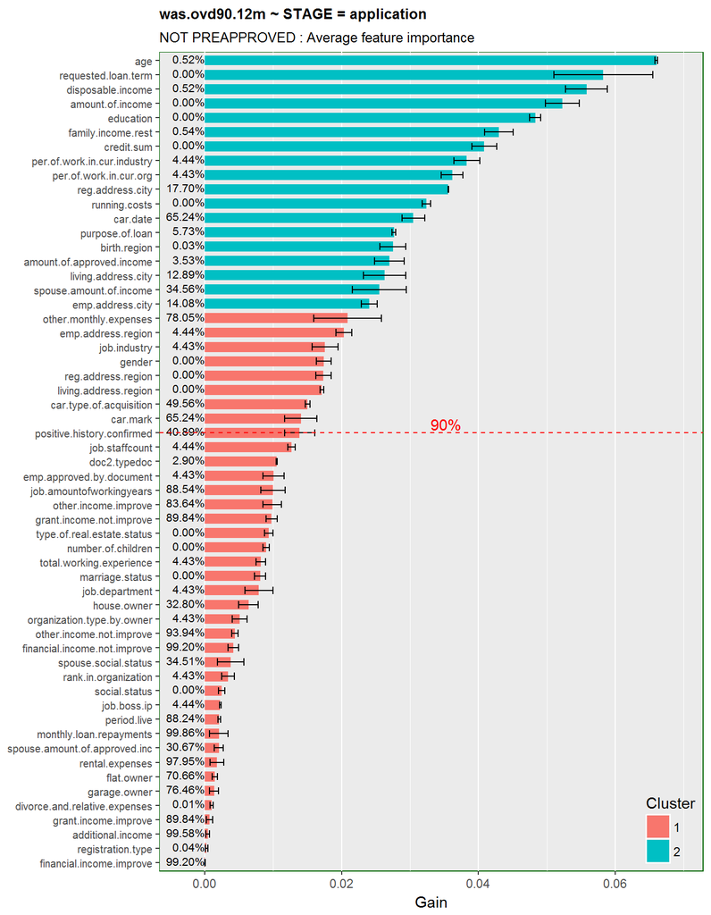

Gain.avg.preapp0.stg.application

Параметры, отражённые на графике STAGE = application

| Feature | Описание | Вес, % |
| --- | --- | --- |
| age | Возраст | 6.6009146 |
| requested.loan.term | Запрошенный срок кредита | 5.8234702 |
| disposable.income | Располагаемый доход | 5.5816387 |
| amount.of.income | Персональный доход по основному месту работы | 5.2252922 |
| education | Образование | 4.8311548 |
| family.income.rest | Семейный баланс | 4.3007352 |
| credit.sum | Сумма кредита | 4.0862132 |
| per.of.work.in.cur.industry | Время работы в этом направлении | 3.8300830 |
| per.of.work.in.cur.org | Время работы в данной организации | 3.6155167 |
| reg.address.city | Адрес регистрации: Город | 3.5608048 |
| running.costs | Коммунальные платежи | 3.2412912 |
| car.date | Автомобиль Год выпуска | 3.0500486 |
| purpose.of.loan | Цель кредита | 2.7659780 |
| birth.region | Место рождения: Регион (область/край) | 2.7510672 |
| amount.of.approved.income | Персональный доход по основному месту работы подтвержден | 2.7014602 |
| living.address.city | Адрес проживания: Город | 2.6296154 |
| spouse.amount.of.income | Персональный доход супруги(а) | 2.5510187 |
| emp.address.city | Адрес организации: Город | 2.4055224 |
| other.monthly.expenses | Прочие расходы (на лечение/сотовую связь и т.д.) | 2.0857877 |
| emp.address.region | Адрес организации: Регион (область/край) | 2.0333617 |
| job.industry | Отрасль места работы | 1.7587423 |
| gender | Пол | 1.7419829 |
| reg.address.region | Адрес регистрации: Регион (область/край) | 1.7364154 |
| living.address.region | Адрес проживания: Регион (область/край) | 1.7128753 |
| car.type.of.acquisition | Автомобиль - способ приобретения | 1.5045381 |
| car.mark | Автомобиль Марка | 1.4043772 |
| positive.history.confirmed | Подтверждена документом положительная кредитная история в других банках | 1.3873602 |
| job.staffcount | Численность организации | 1.2679228 |
| doc2.typedoc | Второй документ Тип документа | 1.0523485 |
| emp.approved.by.document | Место работы подтверждено документом | 1.0067794 |
| job.amountofworkingyears | Возраст начала трудовой деятельности | 0.9977071 |
| other.income.improve | Персональный доход по совместительству подтвержден | 0.9870806 |
| grant.income.not.improve | Платежи от третьих лиц, пособия (алименты, пенсии, субсидии и пр.) | 0.9773305 |
| type.of.real.estate.status | Тип места жительства | 0.9374717 |
| number.of.children | Число детей | 0.9004642 |
| total.working.experience | Общий трудовой стаж | 0.8190487 |
| marriage.status | Семейное положение | 0.8095809 |
| job.department | Подразделение места работы | 0.7906843 |
| house.owner | Индивидуальный дом, предназначенный для постоянного проживания (особняк, коттедж и т.п.) | 0.6393297 |
| organization.type.by.owner | Тип организации по отношению к государству | 0.5098064 |
| other.income.not.improve | Персональный доход по совместительству | 0.4425684 |
| financial.income.not.improve | Доходы от финансового капитала или имущества (сдача имущества в аренду, дивиденды, % с депозитов, % от акций, и пр.) | 0.4175962 |
| spouse.social.status | Супруг(а) Социальный статус | 0.3803705 |
| rank.in.organization | Занимаемая должность | 0.3390269 |
| social.status | Социальный статус | 0.2456869 |
| job.boss.ip | Работодатель - ИП | 0.2265818 |
| period.live | Проживание по текущему адресу | 0.2125663 |
| monthly.loan.repayments | Платежи по кредитам в других банках | 0.2057491 |
| spouse.amount.of.approved.inc | Персональный доход супруги(а) подтвержден | 0.2057206 |
| rental.expenses | Арендные платежи | 0.1780283 |
| flat.owner | Квартира в многоквартирном доме | 0.1481618 |
| garage.owner | Земельный участок со строением в собственности | 0.1368571 |
| divorce.and.relative.expenses | Алименты, помощь родственникам | 0.1043759 |
| grant.income.improve | Платежи от третьих лиц, пособия подтверждены | 0.0695634 |
| additional.income | Дополнительные доходы | 0.0436948 |
| registration.type | Тип регистрации по месту жительства | 0.0266465 |
| financial.income.improve | Доходы от финансового капитала или имущества подтверждены | 0.0039853 |

Параметры ( STAGE = application ), никак не влияющие на целевую переменную

| Feature | Описание | NULL, % |
| --- | --- | --- |
| job.validityoforganization | Срок действия организации | 88.53969 |
| pledge.type | Тип обеспечения по кредиту (если пусто - никакого обеспечения нет) | 99.98068 |